# Nike Activity

Francisco J. Falcon Chavez

March 16, 2016

# Data loading

By using the Nike Fuelband, a device that can track the number of steps made in an certain interval, an individual’s activities were monitored throughout the day. Data was taken from 12:00am of the 1st day of October until 11:55pm of the 30th day of November, every 5 minutes making 288 observations per day.

Assuming the current working directory is where the data is, it can be loaded with:

```r
Nike_rawData <- read.csv('activity.csv')
summary(Nike_rawData)
```

```
##      steps                date          interval
##  Min.   :  0.00   2012-10-01:  288   Min.   :   0.0
##  1st Qu.:  0.00   2012-10-02:  288   1st Qu.: 588.8
##  Median :  0.00   2012-10-03:  288   Median :1177.5
##  Mean   : 37.38   2012-10-04:  288   Mean   :1177.5
##  3rd Qu.: 12.00   2012-10-05:  288   3rd Qu.:1766.2
##  Max.   :806.00   2012-10-06:  288   Max.   :2355.0
##  NA's   :2304     (Other)   :15840
```

Then, we added three columns: 1. A column that numbered each day. 2. A column with the relative time in hours. 3. A column with the day of the week.

```r
Nike_rawData$nDay <- sort(rep(1:length(names(table(as.matrix(Nike_rawData$date)))),288))
Nike_rawData$TimeHour <- rep((0:287)*5/60,length(names(table(as.matrix(Nike_rawData$date)))))
WeekDays<- c('Mon','Tue','Wed','Thu','Fri','Sat','Sun')
for (i in 1:7){
  j=0
  while (j*7+i <= length(names(table(as.matrix(Nike_rawData$date))))){
   Nike_rawData$WeekDay[Nike_rawData$nDay==j*7+i] <- WeekDays[i]
   j=j+1
  }
}
head(Nike_rawData)
```

```
##   steps       date interval nDay   TimeHour WeekDay
## 1    NA 2012-10-01        0    1 0.00000000     Mon
## 2    NA 2012-10-01        5    1 0.08333333     Mon
## 3    NA 2012-10-01       10    1 0.16666667     Mon
## 4    NA 2012-10-01       15    1 0.25000000     Mon
## 5    NA 2012-10-01       20    1 0.33333333     Mon
## 6    NA 2012-10-01       25    1 0.41666667     Mon
```

```r
MeanPerDay <- cbind(as.matrix(unique(Nike_rawData$date[!is.na(Nike_rawData$steps)])),aggregate(steps ~ nDay, data=Nike_rawData[!is.na(Nike_rawData$steps),],FUN=mean))
colnames(MeanPerDay) <- c('date','nDay','steps')
head(MeanPerDay)
```

```
##         date nDay    steps
## 1 2012-10-02    2  0.43750
## 2 2012-10-03    3 39.41667
## 3 2012-10-04    4 42.06944
## 4 2012-10-05    5 46.15972
## 5 2012-10-06    6 53.54167
## 6 2012-10-07    7 38.24653
```

```r
MedianPerDay <- cbind(as.matrix(unique(Nike_rawData$date[!is.na(Nike_rawData$steps)])),aggregate(steps ~ nDay, data=Nike_rawData[!is.na(Nike_rawData$steps),],FUN=median))
colnames(MedianPerDay) <- colnames(MeanPerDay)
head(MedianPerDay)
```

```
##         date nDay steps
## 1 2012-10-02    2     0
## 2 2012-10-03    3     0
## 3 2012-10-04    4     0
## 4 2012-10-05    5     0
## 5 2012-10-06    6     0
## 6 2012-10-07    7     0
```

# Plotting the data

With the objective of seeing the activity of the subject, a plot with the data throughout the two months of observations was made (the dashed red line is the mean of all the data).

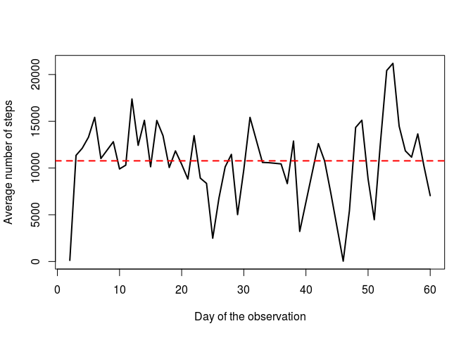

```r
plot(aggregate(steps ~ nDay , Nike_rawData[!is.na(Nike_rawData$steps),],FUN=sum),type='l',lwd=2,xlab='Day of the observation',ylab='Average number of steps')
abline(h=sum(Nike_rawData$steps[!is.na(Nike_rawData$steps)])/length(as.matrix(unique(Nike_rawData$date[!is.na(Nike_rawData$steps)]))),col='red',lty=2,lwd=2)
```

Also, it was considered that having a representation of the number of steps during the day might be of use.

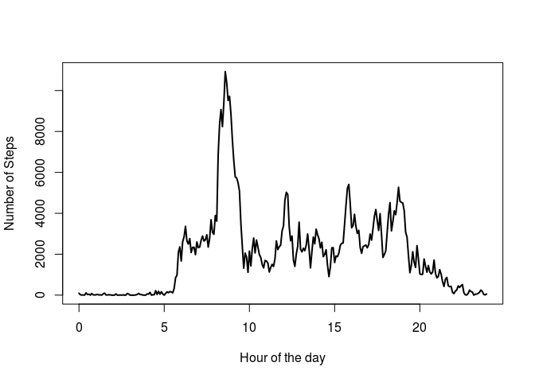

```r
plot(cbind(aggregate(steps ~ TimeHour, data=Nike_rawData, FUN=sum)[,1],aggregate(steps ~ TimeHour, data=Nike_rawData, FUN=sum)[,2]),type='l',lwd=2,ylab='Number of Steps',xlab='Hour of the day')
```

# Number of steps: Weekends Vs. Weekdays

Knowing beforehand that the data started on a monday, the script was adapted to start from 1. However, if this was not the case, the numbers in the for loop must be changed depending on the case. The data was divided into two subsets: one for weekdays and another for weekends.

```r
WeekDays <- c()
for (i in 1:5){
 j=0
 while ((j*7+i)<= max(Nike_rawData$nDay) ){
  WeekDays <-rbind(WeekDays,Nike_rawData[Nike_rawData$nDay==j*7+i,])
  j=j+1
 }
}

WeekendDays <- c()
for (i in 6:7){
 j=0
 while ((j*7+i)<= max(Nike_rawData$nDay) ){
  WeekendDays <-rbind(WeekendDays,Nike_rawData[Nike_rawData$nDay==j*7+i,])
  j=j+1
 }
}
```

For us to compare the differences between weekends and weekdays, we plotted the average number of steps throughout the day in this two different subsets.

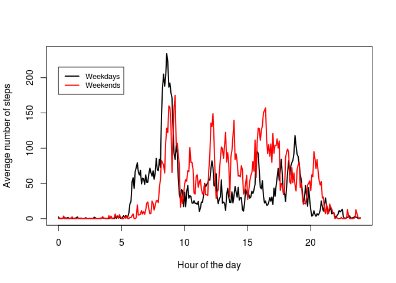

```r
if (max(aggregate( steps ~ TimeHour,data=WeekDays,FUN=mean)$steps) > max(aggregate( steps ~ TimeHour,data=WeekendDays,FUN=mean)$steps)){
  Ylim2 <- max(aggregate(steps ~ TimeHour,data=WeekDays,FUN=mean)$steps)
}else{
  Ylim2 <- max(aggregate(steps ~ TimeHour,data=WeekendDays,FUN=mean)$steps)
}
Ylim2 <- ceiling(Ylim2)
plot(aggregate( steps ~ TimeHour,data=WeekDays,FUN=mean),type='l',ylab='Average number of steps',xlab='Hour of the day',lwd=2,ylim=c(0,Ylim2))
lines(aggregate( steps ~ TimeHour,data=WeekendDays,FUN=mean),type='l',lwd=2,col='red')
legend(x=0,y=Ylim2-20,legend=c('Weekdays','Weekends'),col=c('black','red'),lty=1,lwd=2,cex=0.8)
```

Since the pattern is not clear as cleat, calculation of the mean of each subset was required.

```r
mean(WeekDays$steps[!is.na(WeekDays$steps)])
```

```
## [1] 35.33796
```

```r
mean(WeekendDays$steps[!is.na(WeekendDays$steps)])
```

```
## [1] 43.07837
```

# Dealing with NA (Not Available) data

To deal with missing data, it was decided that it would be best to simulate the data using a normal distribution, using as mean and standard deviation of the same week day and time of the day.

```r
Nike_Data <- Nike_rawData
 for (i in 1:dim(Nike_rawData[is.na(Nike_rawData$steps),])[1]){
   WeekDay <- (Nike_rawData[is.na(Nike_rawData$steps),])[i,6]
   Hour <- (Nike_rawData[is.na(Nike_rawData$steps),])[i,5]
   meanTemp <- mean((Nike_rawData$steps[intersect(which(Nike_rawData$TimeHour==Hour),which(Nike_rawData$WeekDay==WeekDay))])[!is.na(Nike_rawData$steps[intersect(which(Nike_rawData$TimeHour==Hour),which(Nike_rawData$WeekDay==WeekDay))])])
   sdTemp <- sd((Nike_rawData$steps[intersect(which(Nike_rawData$TimeHour==Hour),which(Nike_rawData$WeekDay==WeekDay))])[!is.na(Nike_rawData$steps[intersect(which(Nike_rawData$TimeHour==Hour),which(Nike_rawData$WeekDay==WeekDay))])])
   val <- rnorm(1,meanTemp,sdTemp)
   if (val >=0){
     Nike_Data$steps[as.numeric(rownames(Nike_rawData[is.na(Nike_rawData$steps),]))[i]] <- val
   }else{
     val=0
     Nike_Data$steps[as.numeric(rownames(Nike_rawData[is.na(Nike_rawData$steps),]))[i]] <- val
   }
 }
```